# R Notebook

```r
library(tidyverse)
library(lubridate)
library(tsibble)
library(tsibbledata)
library(fable)
library(feasts)
```

Load in the nyc_bikes data from the tsibbledata package.

```r
nyc_bikes <- nyc_bikes

names(nyc_bikes)
```

```
 [1] "bike_id"       "start_time"    "stop_time"
 [4] "start_station" "start_lat"     "start_long"
 [7] "end_station"   "end_lat"       "end_long"
[10] "type"          "birth_year"    "gender"
```

```r
dim(nyc_bikes)
```

```
[1] 4268   12
```

```r
head(nyc_bikes,3)
```

| bike_id | start_time | stop_time | start_station | start_lat | start_long | end_station | end_lat | end_long | type | birth_year | gender |
| --- | --- | --- | --- | --- | --- | --- | --- | --- | --- | --- | --- |
| 26301 | 2018-02-26 19:11:03 | 2018-02-26 19:15:40 | 3186 | 40.71959 | -74.04312 | 3203 | 40.72760 | -74.04425 | Subscriber | 1986 | Male |
| 26301 | 2018-02-27 07:52:49 | 2018-02-27 07:58:13 | 3203 | 40.72760 | -74.04425 | 3202 | 40.72722 | -74.03376 | Subscriber | 1979 | Male |
| 26301 | 2018-02-27 12:03:27 | 2018-02-27 12:04:54 | 3202 | 40.72722 | -74.03376 | 3638 | 40.72429 | -74.03548 | Subscriber | 1963 | Male |

```r
NA
```

```r
nyc_bikes_year <-
nyc_bikes %>%
  select(-gender, -type, -birth_year) %>%
  mutate(year = year  (start_time),
         month = month(start_time, label = TRUE),
         date  = date(start_time))
```

Summarise the number of bike hire counts by month. Make a plot of this data.

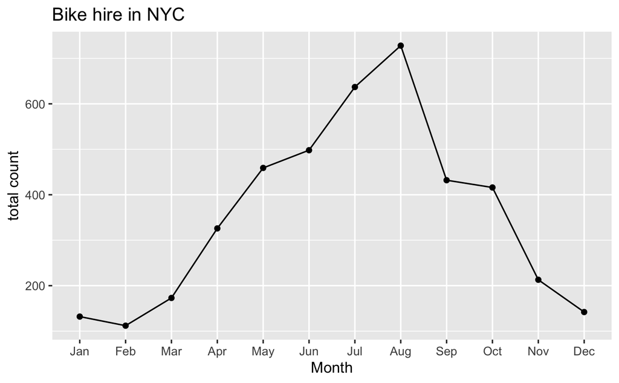

```r
nyc_bikes_month <-
nyc_bikes_year %>%
index_by(month) %>%
  summarise(count = n())


  ggplot(nyc_bikes_month) +
  aes(x = month, y = count) +
  geom_point() +
  geom_line(group = 1) +
  ggtitle("Bike hire in NYC") +
  xlab("Month") + ylab ("total count")
```

```r
NA
NA
```

Summarise the number of bike hire counts by date. Make a plot of this new aggregated data.

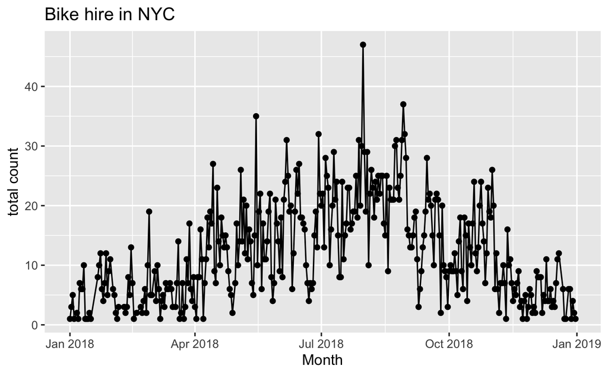

```r
nyc_bikes_date <-
nyc_bikes_year %>%
index_by(date) %>%
  summarise(count = n())

    ggplot(nyc_bikes_date) +
  aes(x = date, y = count) +
  geom_point() +
  geom_line(group = 1) +
  ggtitle("Bike hire in NYC") +
  xlab("Month") + ylab ("total count")
```

```r
NA
NA
NA
NA
```

build a model. For this, we will use the downsampled by date dataset we created above.

```r
# fill the gaps with median

nyc_bikes_filled <- nyc_bikes_date %>%
  fill_gaps(count = as.integer(median(count)))

nyc_bikes_filled
```

| date | count |
| --- | --- |
| 2018-01-01 | 1 |
| 2018-01-02 | 3 |
| 2018-01-03 | 5 |
| 2018-01-04 | 1 |
| 2018-01-05 | 10 |
| 2018-01-06 | 2 |
| 2018-01-07 | 1 |
| 2018-01-08 | 7 |
| 2018-01-09 | 6 |
| 2018-01-10 | 6 |

[output cut: 355 more lines]

```r
NA
```

```r
fit <- nyc_bikes_filled %>%
  model(
    snaive = SNAIVE(count),
    mean_model = MEAN(count),
    arima = ARIMA(count)
  )

fit
```

| snaive | mean_model | arima |
| --- | --- | --- |

```r
NA
```

Forecasting to predict bike use over the next four months bu using model fit above. Plot your models alongside your data.

```r
forecast_bike_use <- fit %>%
  fabletools::forecast(h = 120)

forecast_bike_use
```

| .model | date | count | .distribution |
| --- | --- | --- | --- |
| snaive | 2019-01-01 | 10.000000 |  |
| snaive | 2019-01-02 | 6.000000 |  |
| snaive | 2019-01-03 | 6.000000 |  |
| snaive | 2019-01-04 | 1.000000 |  |
| snaive | 2019-01-05 | 4.000000 |  |
| snaive | 2019-01-06 | 2.000000 |  |
| snaive | 2019-01-07 | 1.000000 |  |
| snaive | 2019-01-08 | 10.000000 |  |
| snaive | 2019-01-09 | 6.000000 |  |
| snaive | 2019-01-10 | 6.000000 |  |

[output cut: 350 more lines]

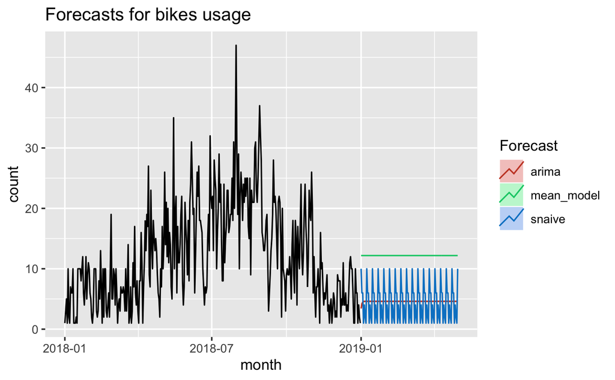

```r
forecast_bike_use %>%
  autoplot(nyc_bikes_filled, level = NULL) +
  ggtitle("Forecasts for bikes usage") +
  xlab("month") +
  guides(colour = guide_legend(title = "Forecast"))
```

```r
NA
NA
```